# presentation

robinhwp

2023-03-22

# 5강. 제2장 중회귀모형-2

## 1. 표준화된 중회귀분석

- 종속변수와 독립변수의 표준화 정규분포의 표준화변환 (통개학개론 p103)에서 $Z = { X - \mu \over \sigma }$ 식으로 변환하여 정규분포 $N(0, 1)$을 따르게 되는 것처럼 변수의 표준화로 회귀계수($\hat{\alpha}_i$)의 단위가 통일되어 비교가 가능해지게 된다.
  - 하지만 이 비교를 가지고 너무 단정적으로 결론을 내리는데는 주의하여야 한다.
  - $\begin{aligned} Y_i^* = {Y_i - \bar{Y} \over \sqrt{S_{YY}}} \end{aligned}$, $\begin{aligned} Z_{ij} = {X_{ij} - \bar{X_j} \over \sqrt{S_{jj}}} \end{aligned}$
    - $S_{YY}=\sum(Y_i-\bar{Y})^2$
    - $S_{jj}=\sum_i (X_{ij} - \bar{X_j})^2$
    - $\bar{X_j}$: $j$번째 독립변수의 평균값
  - $\begin{aligned} \sum_{i} Z_{i\color{indianred}{j}} = 0, \sum_{i} (Z_{i\color{indianred}{j}})^2 = 1, (j=1,2,\cdots, k) \end{aligned}$
  - $\sum Y_i^*=0, \sum(Y_i^*)^2=1$

### 변수 표준화

- 표준화된 변수(standardized variables)의 중회귀모형
  - $Y_i^*=\alpha_1 Z_{i1} + \alpha_2 Z_{i2} + \cdots + \alpha_k Z_{ik} + \varepsilon_i'$
  - 표준화된 중회귀모형은 $Y$의 절편이 $0$ 이 되는 특징이 있다
- 표준화된 중회귀모형 추정하면
  - $\hat{Y}_i^*=\hat{\alpha}_1 Z_{i1} + \hat{\alpha}_2 Z_{i2} + \cdots + \hat{\alpha}_k Z_{ik}$ $\alpha_i$의 절대값이 크면 클수록 독립변수 $X_i$가 $Y_i$에 주는 영향이 크게 된다.

## 2. 추정과 검정

### 추정된 회귀계수의 분산

- 회귀계수벡터 $\boldsymbol{\beta}'=(\beta_0,\beta_1,\beta_2,\cdots,\beta_k)$의 $\boldsymbol{\beta}$의 추정량 $\boldsymbol{\hat{\beta}}$  
  $\color{blue}{E(\boldsymbol{\hat{\beta}}) = \boldsymbol{\beta}}$

  $\begin{aligned} E(\boldsymbol{\hat{\beta}}) &= E[(\boldsymbol{X'X})^{-1}\boldsymbol{X'Y}] \\&=(\boldsymbol{X'X})^{-1}\boldsymbol{X'}E(\boldsymbol{Y}) \\&= (\boldsymbol{X'X})^{-1}\boldsymbol{X'X\beta} \\&=\boldsymbol{\beta} \end{aligned}$

  $\boldsymbol{\hat{\beta}}$는 $\boldsymbol{\beta}$의 불편추정량
- $\boldsymbol{\hat{\beta}}$의 분산-공분산 행렬은  
  $\color{blue} {Var(\boldsymbol{\hat{\beta}})= (\boldsymbol{X'X})^{-1}\sigma^2}$  
  $\begin{aligned} Var(\boldsymbol{\hat{\beta}}) &=Var[(\boldsymbol{X'X})^{-1}\boldsymbol{X'Y}] \\&=(\boldsymbol{X'X})^{-1}\boldsymbol{X'}Var[\boldsymbol{Y}][(\boldsymbol{X'X})^{-1}\boldsymbol{X'}]' \\&=(\boldsymbol{X'X})^{-1}\boldsymbol{X'}[\boldsymbol{I}\sigma^2]\boldsymbol{X}(\boldsymbol{X'X})^{-1} \\&=(\boldsymbol{X'X})^{-1}\boldsymbol{X'}\boldsymbol{X}(\boldsymbol{X'X})^{-1}\sigma^2 \\&=(\boldsymbol{X'X})^{-1}\sigma^2 \end{aligned}$

그런데 $Var(\boldsymbol{\hat{\beta}})$는 벡터 $\boldsymbol{\hat{\beta}}$의 구성원들 간의 분산과 공분산을 나타내는 행렬로서 $(\boldsymbol{X’X})^{-1}$행렬의 구성원을  
$c_{ij}(i,j=0,1,2,\cdots, k)$라 하면 다음과 같이 쓸수 있다.

- $Var(\hat{\beta}_i)=c_{ii}\sigma^2, (i = 0, 1, 2, \cdots, k)$
- $Cov(\hat{\beta}_i, \hat{\beta}_j)=c_{ij}\sigma^2, (i \ne j)$

만약 우리가 특별히 관심 있는 독립변수 $X_i$라면 $b_i$의 분산이 작게되는 회귀방정식이 요구될 것이며,  
$c_{ii}$의 값이 크지 않도록 계획행렬(design matrix) $\boldsymbol{X}$를 설계해 줄 필요가 있을 것이다.  
$\boldsymbol{X}$ 행렬의 설계에 따라서 $Var(\boldsymbol{\hat{\beta}})$가 크게 달라지기 때문이다.

### $E(Y)$의 구간추정

- 독립변수들의 임의의 값 ($x_1, x_2, \cdots, x_k$)에서 $E(\boldsymbol{Y})$의 구간추정

$\hat{Y} \pm t(n-k-1;\alpha/2)\sqrt{\boldsymbol{x'}(\boldsymbol{X'X})^{-1}\boldsymbol{x}\cdot MSE}$

$\begin{aligned}\boldsymbol{\hat{Y}}&=\hat{\beta}_0 + \hat{\beta}_1 x_1 + \hat{\beta}_2 x_2 + \cdots + \hat{\beta}_k x_k \\&= \begin{pmatrix} 1, x_1,x_2,\cdots,x_k \end{pmatrix} \begin{pmatrix} \hat{\beta}_0 \\ \hat{\beta}_1 \\ \hat{\beta}_2 \\ \vdots \\ \hat{\beta}_k \end{pmatrix} \\&= \boldsymbol{x'\hat{\beta}}\end{aligned}$

⇒ $\begin{aligned} Var(\hat{Y})&=Var(\boldsymbol{x'\hat{\beta}})=\boldsymbol{x'}Var(\boldsymbol{\hat{\beta}})\boldsymbol{x} \\&=\boldsymbol{x}'(\boldsymbol{X'X})^{-1}\boldsymbol{x}\sigma^2 \end{aligned}$

⇒ $E(Y)$의 $100(1-\alpha)$% 신뢰구간  
$\color{blue}{\hat{Y} \pm t(n-k-1;\alpha/2)\sqrt{\boldsymbol{x'}(\boldsymbol{X'X})^{-1}\boldsymbol{x}\cdot MSE}}$

### 회귀계수 $\beta_i$의 가설 및 검정통계량

- 가설
  - $H_0 : \beta_i = \beta_{i0}$
  - $H_1 : \beta_i \ne \beta_{i0}$
- 검정통계량
  - $\begin{aligned} t_0={b_i - \beta_{i0} \over \sqrt{c_{ii}\cdot MSE}} \end{aligned}$, $c_{ii}$ 는 $Var(\boldsymbol{\hat{\beta}})= (\boldsymbol{X'X})^{-1}\sigma^2$의 대각선 값

### 일반적 모형비교

- 두 모형의 비교는 `완전모형`과 `축소모형`의 잔차제곱합의 차이를 이용함 두 모형을 비교하기위한 검정통계량은 $\begin{aligned} F_0 = {MSR \over MSE} \end{aligned}$ 을 사용한다.

  `완전모형` : 데이터에 잘 적합되리라고 고려되는 모형 ( $Y_i = \beta_0 + \beta_1 X_i + \varepsilon_i$ )
  - 완전모형의 경우의 잔차제곱합
    - $\hat{Y}=b_0 + b_1X$
    - $SSE(F)=\sum [Y_i-(b_0 + b_1 X_i)]^2 = \sum (Y_i - \hat{Y}_i)^2 = SSE$

## 3. 변수추가

### 추가제곱합

- 중회귀모형을 적합하는데 있어서 어떤 특정한 변수를 회귀모형에 포함시키는 것이 바람직한가를 결정하고 싶은 경우
  - 이 변수를 포함시키지 않고 구한 회귀제곱합보다 이 변수를 포함시키고 구한 회귀제곱합(regression sum of squares )이 추가적으로 어느 정도 커졌는가를 검토. 이와 같은 경우에 추가적으로 증가된 제곱합을 추가제곱합(extra sum of squares)이라고 함.
  - 추가제곱합은 새로운 변수가 모형에 추가될 때의 회귀제곱합의 증가분을 나타내는 것으로서 이 값이 작을수록 회귀에 대한 기여도가 떨어진다는 것을 의미.

### 추가변수그림(added variable plot)

- 중회귀모형에서 새로운 변수선택은 기존의 모형이 설명하지 못하는 부분을 새로운 변수가 들어옴으로써 추가설명력이 얼마나 유의한 가에 따라 결정
  - 새로운 변수의 효과를 그래프로 표현할 수 있는데, 이러한 그래프 중의 하나가 추가변수그림(added variable plot)임. 이를 편회귀그림(partial regression plot)이라고도 함.
- 추가변수 그림 그리는 절차
  - 독립변수가 2개인 회귀모형에서 변수 $X_2$의 추가변수그림을 그리는 절차
    - $Y = \beta_0 + \beta_1 X_1 + \beta_2 X_2 + \varepsilon$
  1. $Y$를 $X_1$으로 회귀한 후 얻어지는 잔차, $e(Y|X_1)$을 구한다.
  2. $X_2$를 $X_1$으로 회귀한 후 얻어지는 잔차, $e(X_2|X_1)$을 구한다.
  3. 앞에서 구한 두 잔차에서 $x$-축을 $e(X_2|X_1)$, $y$-축을 $e(Y|X_1)$으로 한 산점도를 추가변수 그림이라 함.

  → 추가변수그림이 선형관계가 있으면 변수 $X_2$는 추가적인 설명력이 있다고 판단.

## 4. 잔차검토 및 분석 사례

### 잔차의 검토

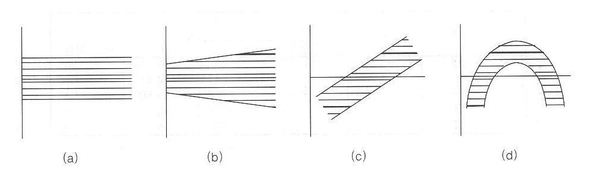

**잔차(**$e_i$)를 $\hat{Y}_i$에 대한 산점도를 그렸을때,

ⓐ 가정에 아무런 모순이 없는것으로 판정된다.

ⓑ 분산이 일정하지 않으며, 가중회귀(weighted regression)를 쓰거나 또는 $Y_i$를 변환시켜 회귀분석함이 바람직하다.

ⓒ 절편이 필요한 모형인데 절편을 사용하지 않았을 경우에 생길 수 있는 형태이다.

ⓓ 모형이 타당하지 않다. 추가적으로 독립변수의 제곱항이 필요하다. 또는 $Y_i$의 적절한 변환이 필요하다.

**잔차(**$e_i$)를 독립변수 $X_{ij}, j= 1,2,...,k$ 에 대한 산점도를 그렸을때

ⓐ 가정에 아무런 모순이 없는 경우로 사용된 중회귀모형이 적절한다.

ⓑ 분산이 일정하지 않으며, 가중회귀(weighted regression)를 쓰거나 또는 $Y_i$를 변환시켜 회귀분석함이 바람직하다.

ⓒ 중회귀분석 과정에서 계산상에 착오가 있는 경우이다. $X_{ij}$의 선형효과가 적절히 취급되지 않았다, 즉 $X_{ij}$항을 빠뜨려서 계산했거나 계산상에 실수가 있다.

ⓓ 필요한 독립변수의 항들이 포함되어 있지 않다. 특히 필요한 제곱항이 빠졌을 경우에 발생한다.